# An Analysis of GoBike Data

## Overview

**This is an analysis of GoBike Data in the periods of Jan:Aug 2019 & Jan:Aug 2020. We chose these specific periods to inspect the impact of COVID-19 on the bussiness.** (Latest released data for 2020 was August, so we will work with 2019 data till August as well.)

This analysis is done to **highlight COVID-19 impact, to gain insights about users & to help the company target offers in certain stations.**

## Analysis approach

**Univariate relationships:**

- Number of rides per user type; who does the most rides?
- Explore most used bike_type.
- Explore start_weekday of trips.
- Explore start_hour of trips.
- Find top 10 stations (top-start & top-end) and the common stations between them to target offers to users visiting these places.

**Bivariate relationships:**

- Find most crowded stations at rush hours.
- Explore bike rides in 2019 and 2020 throughout the period of Jan:Aug, and see if COVID-19 affected the bussiness; number of rides.
- Compare rental_methods and user_types.
- Is there a relationship between trip hour-time and user_type?
- Explore the relationship between user_type, trip duration.

**Multivariate relationships:**

- Explore the relationship between start_weekday, trip_duration and user_type.

## The Data

**This data is provided according to the Bay Wheels License Agreement. Each trip is anonymized and includes:**

- Trip Duration (in seconds)
- Start Time and Date
- End Time and Date
- Start Station ID
- Start Station Name
- Start Station Latitude
- Start Station Longitude
- End Station ID
- End Station Name
- End Station Latitude
- End Station Longitude
- Bike ID
- User Type (Subscriber or Customer – “Subscriber” = Member or “Customer” = Casual)

**We won't use all of these columns, as some of them are irrelevant to our analysis, will only use:**

- 'start_station_name'
- 'end_station_name'
- 'rental_access_method'
- 'rideable_type'
- **'duration_sec':** will extract duration in minutes
- **'start_time', 'started_at':** same info, will combine them (fill Nulls in one column with its value in the other because they changed the column name in some months), will also change the column's type to datetime to extract year, month, day and weekday.
- **'end_time', 'ended_at':** same info, will combine them (fill Nulls in one column with its value in the other), will also change the column's type to datetime.
- **'member_casual', 'user_type':** same info, will combine them (fill Nulls in one column with its value in the other) and encode member >> subscriber & casual >> customer.

## Exploratory Data Analysis

**Univariate relationships:**

- Number of rides per user type; who does the most rides?
- Explore most used bike_type.
- Explore start_weekday of trips.
- Explore start_hour of trips.
- Find top 10 stations (top-start & top-end) and the common stations between them to target offers to users visiting these places.

**Bivariate relationships:**

- Find most crowded stations at rush hours.
- Explore bike rides in 2019 and 2020 throughout the period of Jan:Aug, and see if COVID-19 affected the bussiness; number of rides.
- Compare rental_methods and user_types.
- Is there a relationship between trip hour-time and user_type?
- Explore the relationship between user_type, trip duration.

**Multivariate relationships:**

- Explore the relationship between start_weekday, trip_duration and user_type.

## Univariate relationships:

### Number of rides per user type; who does the most rides?

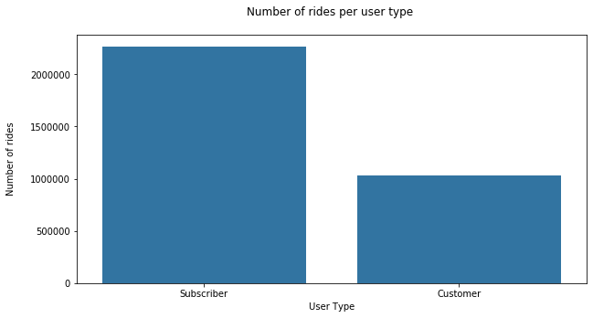

```python
plt.figure(figsize= [10, 5])
sb.countplot(x='user_type', data=data, color=base_color);
plt.xlabel("User Type");
plt.ylabel("Number of rides\n");
plt.title("Number of rides per user type \n");
```

**Subscribed users do the most rides.**

### Most used bike_type

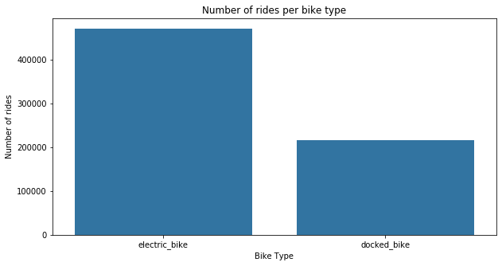

```python
plt.figure(figsize= [10, 5])
sb.countplot(x='rideable_type', data=data, color=base_color);
plt.xlabel("Bike Type");
plt.ylabel("Number of rides");
plt.title("Number of rides per bike type");
```

**Most users prefer electric bike.**

### Explore start_weekday of trips

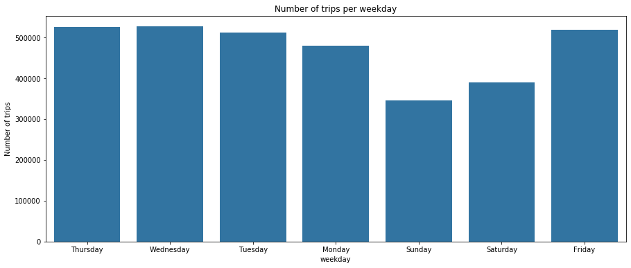

```python
plt.figure(figsize= [15, 6])
sb.countplot(x='start_weekday', data=data, color=base_color);
plt.xlabel("weekday");
plt.ylabel("Number of trips");
plt.title("Number of trips per weekday");
```

### Explore start_hour of trips (find rush hours)

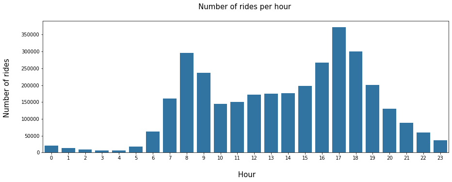

```python
plt.figure(figsize = [15, 5])

sb.countplot(x='start_hour', data=data, color= base_color);

plt.title("Number of rides per hour \n", fontsize=15);
plt.xlabel("\n Hour", fontsize=15);
plt.ylabel("Number of rides \n", fontsize=15);
```

### Find top 10 stations (top-start & top-end) and the common stations between them to target offers to users visiting these places.

### Top Start Stations

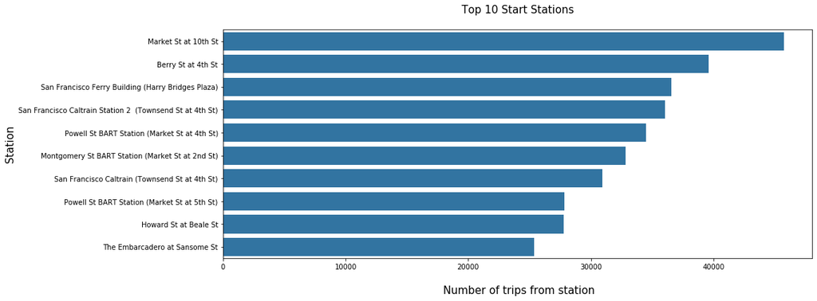

```python
top_start_stations = get_top_n_stations('start', n)

plt.figure(figsize=(15,6))

sb.barplot(top_start_stations.values, y= top_start_stations.index, color= base_color);
plt.title("Top {} Start Stations\n".format(n), fontsize=15);
plt.xlabel("\n Number of trips from station", fontsize=15);
plt.ylabel("Station", fontsize=15);
```

### Top End Stations

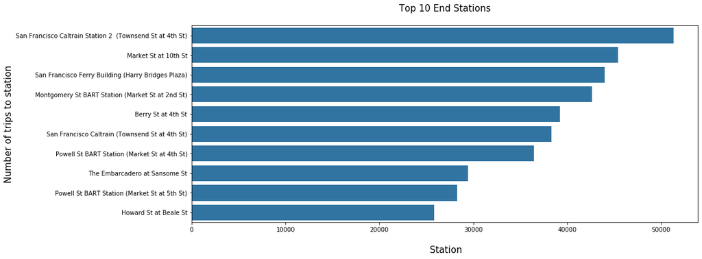

```python
top_end_stations = get_top_n_stations('end', n)

plt.figure(figsize=(15,6))

sb.barplot(top_end_stations.values, y= top_end_stations.index, color= base_color);

plt.title("Top {} End Stations\n".format(n), fontsize=15);
plt.xlabel("\n Station", fontsize=15);
plt.ylabel("Number of trips to station", fontsize=15);
```

### Common Stations between start&end stations

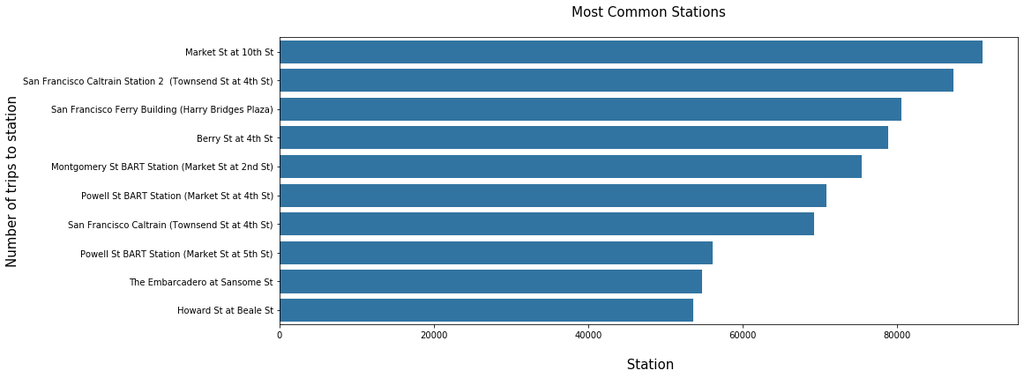

```python
commons = get_common_stations(top_start_stations, top_end_stations)

plt.figure(figsize=(15,6))

sb.barplot(data= commons, x= 'total_n_trips', y= 'station_name', color= base_color);

plt.title("Most Common Stations\n", fontsize=15);
plt.xlabel("\n Station", fontsize=15);
plt.ylabel("Number of trips to station", fontsize=15);
```

### Most crowded stations at rush hours:

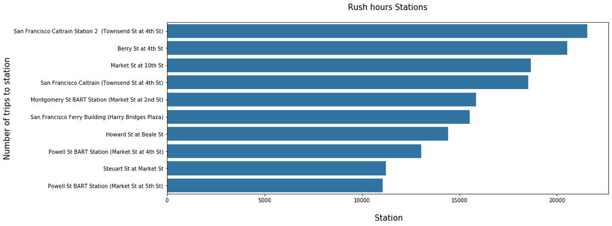

```python
rush_hours_stations = data[data['start_hour'].isin([8,9,17,18])]['start_station_name'].value_counts()[:10]

plt.figure(figsize=(15,6))

sb.barplot(x= rush_hours_stations.values, y= rush_hours_stations.index, color= base_color);

plt.title("Rush hours Stations\n", fontsize=15);
plt.xlabel("\n Station", fontsize=15);
plt.ylabel("Number of trips to station", fontsize=15);
```

**We can attract users by providing offers to and from these stations.**

### Bivariate relationships:

### Inspect COVID-19 Effect

Let's compare the number of rides in 2019 and 2020

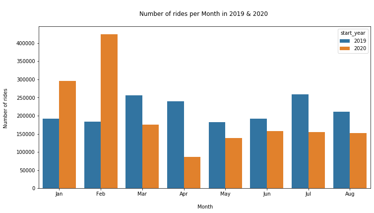

```python
plt.figure(figsize = [12, 6])

sb.countplot(x='start_month', data=data, hue='start_year');
plt.xlabel("\n Month");
plt.ylabel("Number of rides \n");
plt.title("\nNumber of rides per Month in 2019 & 2020 \n");
plt.xticks(ticks=plt.xticks()[0], labels= ("Jan", "Feb", "Mar", "Apr", "May", "Jun", "Jul", "Aug"));
```

**In 2020, bike rides numbers were at their highest, starting the year in Jan & Feb with higher number than those of 2019, however, we can notice that the number of rides had a surprising drop in March and kept dropping through April, the two months that had the most lockdowns and extreme measurements. The number of rides increased a bit at May, but comparing to 2019's numbers, COVID-19 affected the bike rides.**

#### Total number of rides in 2019 & 2020 (Univariate)

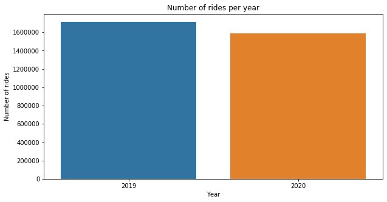

```python
plt.figure(figsize= [10, 5])
sb.countplot(x='start_year', data=data);
plt.xlabel("Year");
plt.ylabel("Number of rides");
plt.title("Number of rides per year");
```

**Apparently, COVID-19 has caused the bike rides to drop by 127,993 in 2020 rides.**

### Compare rental_methods and user_types

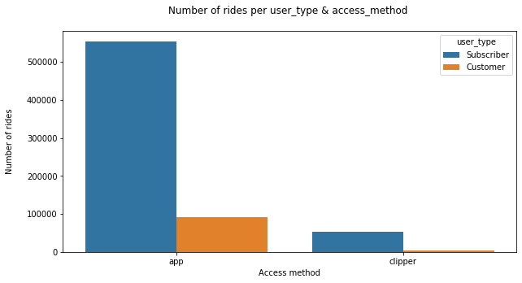

```python
plt.figure(figsize= [10, 5])
sb.countplot(x='rental_access_method', data=data, hue='user_type');
plt.xlabel("Access method");
plt.ylabel("Number of rides\n");
plt.title("Number of rides per user_type & access_method \n");
```

**The app is the preferred access method for both Subscribers & Customers, as most rides were made through the app. We might consider sending offers through the app.**

### Is there a relationship between trip hour-time and user_type?

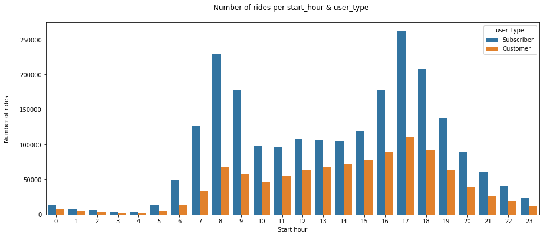

```python
plt.figure(figsize= [15, 6])
sb.countplot(x='start_hour', data=data, hue='user_type');
plt.xlabel("Start hour");
plt.ylabel("Number of rides\n");
plt.title("Number of rides per start_hour & user_type \n");
```

**As we noticed earlier, most rides are done in begining and ending of working-hours (8 or 9 AM & 5 or 6 PM).**

**It doesn't seem to be a relationship between start_hour and user_type as both user types make rides at these times. However, most rides at these hours are done by subscribers, which strengthen the possibility that users use the bikes to get to and from work.**

**Providing offers at these hours can attract more users.**

### Explore the relationship between user_type & trip duration

**First, let's look at trip duration's distribution (all data)**

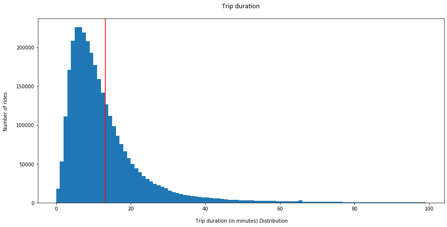

```python
plt.figure(figsize= [15, 7])

binsize = 1
bins = np.arange(0, 100, binsize)

plt.hist(data[data['duration_min'] <= 100]['duration_min'], bins= bins);
plt.xlabel("\n Trip duration (in minutes) Distribution")
plt.ylabel("Number of rides \n")
plt.title("Trip duration\n");
plt.axvline(x=data[data['duration_min'] <= 100]['duration_min'].mean(), color='red');
```

**Trip duration follow a skewed-to-the-right normal distribution, with a mean of approximately 13.5, most rides are within the range of [0:20], although we removed durations > 100, there are some larger values (60/80, etc..)**

### First, let's look at trip duration's distribution

**Highlighting the two user types; Subscriber distribution in blue & Customer in orange**

**Subscribers' mean is in black, while Customers' mean in green**

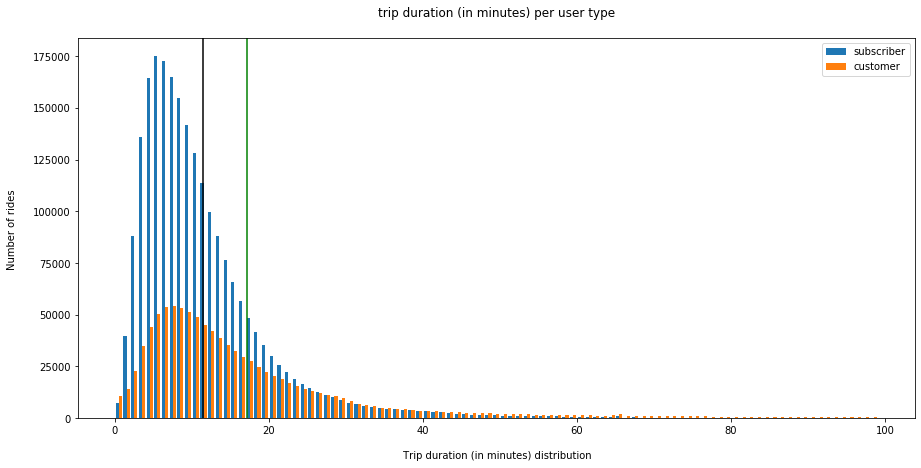

```python
plt.figure(figsize= [15, 7])

binsize = 1
bins = np.arange(0, 100, binsize)

subscribers = data.query('user_type == "Subscriber"')['duration_min']
customers = data.query('user_type == "Customer"')['duration_min']

plt.hist([subscribers, customers], bins= bins, label=['subscriber', 'customer']);
plt.xlabel("\n Trip duration (in minutes) distribution")
plt.ylabel("Number of rides \n")
plt.title("trip duration (in minutes) per user type\n");

mean_duration_subscriber = subscribers[subscribers <= 100].mean()
plt.axvline(x=mean_duration_subscriber, color='black');

mean_duration_customer = customers[customers <= 100].mean()
plt.axvline(x=mean_duration_customer, color='green');

plt.legend(loc='upper right');
```

**We can see that customers have higher average trip duration than subscribers.**

## Multivariate relationships

### Explore the relationship between start_weekday, trip_duration and user_type

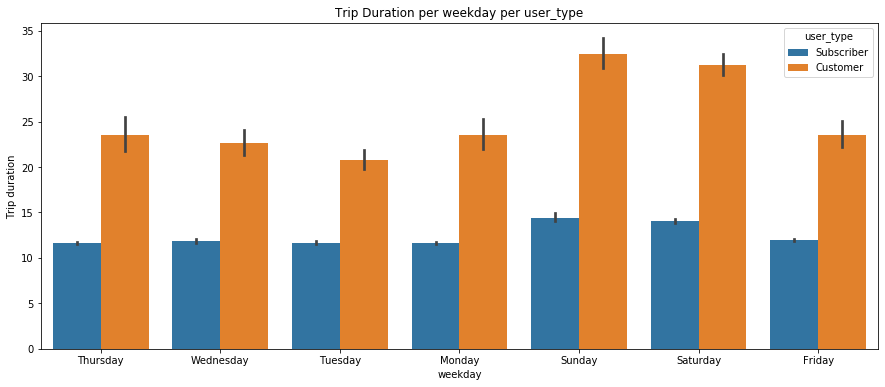

```python
plt.figure(figsize= [15, 6])

sb.barplot(x='start_weekday', y='duration_min', data=data, hue='user_type');
plt.xlabel("weekday");
plt.ylabel("Trip duration");
plt.title("Trip Duration per weekday per user_type");
```

**We can also see that customers have more trip durations than subscribers, we can offer them subscribtion plans or bundles.**